# PropertyAnimation QML Type

Animates changes in property values. More...

| Import Statement: | `import QtQuick` |
| --- | --- |
| Inherits: | Animation |
| Inherited By: | ColorAnimation, NumberAnimation, RotationAnimation, and Vector3dAnimation |

- [List of all members, including inherited members](https://doc.qt.io/qt-6.9/qml-qtquick-propertyanimation-members.html)

## Properties

- **duration** : int
- **easing**
  - **easing.amplitude** : real
  - **easing.bezierCurve** : list<real>
  - **easing.overshoot** : real
  - **easing.period** : real
  - **easing.type** : enumeration
- **exclude** : list<QtObject>
- **from** : variant
- **properties** : string
- **property** : string
- **target** : QtObject
- **targets** : list<QtObject>
- **to** : variant

## Detailed Description

PropertyAnimation provides a way to animate changes to a property's value.

It can be used to define animations in a number of ways:

- In a Transition

  For example, to animate any objects that have changed their `x` or `y` properties as a result of a state change, using an `InOutQuad` easing curve:

  ```
  Rectangle {
      id: rect
      width: 100; height: 100
      color: "red"

      states: State {
          name: "moved"
          PropertyChanges { target: rect; x: 50 }
      }

      transitions: Transition {
          PropertyAnimation { properties: "x,y"; easing.type: Easing.InOutQuad }
      }
  }
  ```

- In a Behavior

  For example, to animate all changes to a rectangle's `x` property:

  ```
  Rectangle {
      width: 100; height: 100
      color: "red"

      Behavior on x { PropertyAnimation {} }

      MouseArea { anchors.fill: parent; onClicked: parent.x = 50 }
  }
  ```

- As a property value source

  For example, to repeatedly animate the rectangle's `x` property:

  ```
  Rectangle {
      width: 100; height: 100
      color: "red"

      SequentialAnimation on x {
          loops: Animation.Infinite
          PropertyAnimation { to: 50 }
          PropertyAnimation { to: 0 }
      }
  }
  ```

- In a signal handler

  For example, to fade out `theObject` when clicked:

  ```
  MouseArea {
      anchors.fill: theObject
      onClicked: PropertyAnimation { target: theObject; property: "opacity"; to: 0 }
  }
  ```

- Standalone

  For example, to animate `rect`'s `width` property over 500ms, from its current width to 30:

  ```
  Rectangle {
      id: theRect
      width: 100; height: 100
      color: "red"

      // this is a standalone animation, it's not running by default
      PropertyAnimation { id: animation;
                          target: theRect;
                          property: "width";
                          to: 30;
                          duration: 500 }

      MouseArea { anchors.fill: parent; onClicked: animation.running = true }
  }
  ```

Depending on how the animation is used, the set of properties normally used will be different. For more information see the individual property documentation, as well as the Animation and Transitions in Qt Quick introduction.

Note that PropertyAnimation inherits the abstract Animation type. This includes additional properties and methods for controlling the animation.

## Modifying running animations

Since Qt 6.4, it is possible to set the from, to, duration, and easing properties on a top-level animation while it is running. The animation will take the changes into account on the next loop.

**See also** Animation and Transitions in Qt Quick and [Qt Quick Examples - Animation](https://doc.qt.io/qt-6.9/qtquick-animation-example.html).

## Property Documentation

### properties : string

These properties are used as a set to determine which properties should be animated. The singular and plural forms are functionally identical, e.g.

```
NumberAnimation { target: theItem; property: "x"; to: 500 }
```

has the same meaning as

```
NumberAnimation { targets: theItem; properties: "x"; to: 500 }
```

The singular forms are slightly optimized, so if you do have only a single target/property to animate you should try to use them.

The `targets` property allows multiple targets to be set. For example, this animates the `x` property of both `itemA` and `itemB`:

```
NumberAnimation { targets: [itemA, itemB]; properties: "x"; to: 500 }
```

In many cases these properties do not need to be explicitly specified, as they can be inferred from the animation framework:

Value Source / Behavior

When an animation is used as a value source or in a Behavior, the default target and property name to be animated can both be inferred.

```
Rectangle {
    id: theRect
    width: 100; height: 100
    color: Qt.rgba(0,0,1)
    NumberAnimation on x { to: 500; loops: Animation.Infinite } //animate theRect's x property
    Behavior on y { NumberAnimation {} } //animate theRect's y property
}
```

Transition

When used in a transition, a property animation is assumed to match *all* targets but *no* properties. In practice, that means you need to specify at least the properties in order for the animation to do anything.

```
Rectangle {
    id: theRect
    width: 100; height: 100
    color: Qt.rgba(0,0,1)
    Item { id: uselessItem }
    states: State {
        name: "state1"
        PropertyChanges {
            theRect {
                x: 200
                y: 200
                z: 4
            }
            uselessItem {
                x: 10
                y: 10
                z: 2
            }
        }
    }
    transitions: Transition {
        //animate both theRect's and uselessItem's x and y to their final values
        NumberAnimation { properties: "x,y" }

        //animate theRect's z to its final value
        NumberAnimation { target: theRect; property: "z" }
    }
}
```

Standalone

When an animation is used standalone, both the target and property need to be explicitly specified.

```
Rectangle {
    id: theRect
    width: 100; height: 100
    color: Qt.rgba(0,0,1)
    //need to explicitly specify target and property
    NumberAnimation { id: theAnim; target: theRect; property: "x"; to: 500 }
    MouseArea {
        anchors.fill: parent
        onClicked: theAnim.start()
    }
}
```

As seen in the above example, properties is specified as a comma-separated string of property names to animate.

**See also** exclude and Animation and Transitions in Qt Quick.

### duration : int

This property holds the duration of the animation, in milliseconds.

The default value is 250.

### easing.amplitude : real

Specifies the easing curve used for the animation

To specify an easing curve you need to specify at least the type. For some curves you can also specify amplitude, period and/or overshoot (more details provided after the table). The default easing curve is `Easing.Linear`.

```
PropertyAnimation { properties: "y";
                    easing.type: Easing.InOutElastic;
                    easing.amplitude: 2.0;
                    easing.period: 1.5 }
```

Available types are:

`Easing.Linear`

Easing curve for a linear (t) function: velocity is constant.

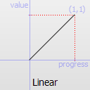

`Easing.InQuad`

Easing curve for a quadratic (t^2) function: accelerating from zero velocity.

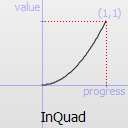

`Easing.OutQuad`

Easing curve for a quadratic (t^2) function: decelerating to zero velocity.

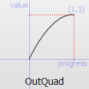

`Easing.InOutQuad`

Easing curve for a quadratic (t^2) function: acceleration until halfway, then deceleration.

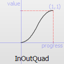

`Easing.OutInQuad`

Easing curve for a quadratic (t^2) function: deceleration until halfway, then acceleration.

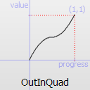

`Easing.InCubic`

Easing curve for a cubic (t^3) function: accelerating from zero velocity.

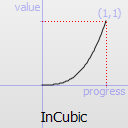

`Easing.OutCubic`

Easing curve for a cubic (t^3) function: decelerating to zero velocity.

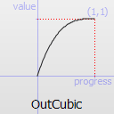

`Easing.InOutCubic`

Easing curve for a cubic (t^3) function: acceleration until halfway, then deceleration.

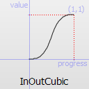

`Easing.OutInCubic`

Easing curve for a cubic (t^3) function: deceleration until halfway, then acceleration.

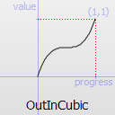

`Easing.InQuart`

Easing curve for a quartic (t^4) function: accelerating from zero velocity.

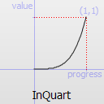

`Easing.OutQuart`

Easing curve for a quartic (t^4) function: decelerating to zero velocity.

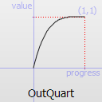

`Easing.InOutQuart`

Easing curve for a quartic (t^4) function: acceleration until halfway, then deceleration.

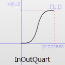

`Easing.OutInQuart`

Easing curve for a quartic (t^4) function: deceleration until halfway, then acceleration.

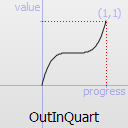

`Easing.InQuint`

Easing curve for a quintic (t^5) function: accelerating from zero velocity.

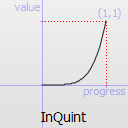

`Easing.OutQuint`

Easing curve for a quintic (t^5) function: decelerating to zero velocity.

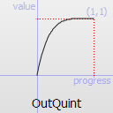

`Easing.InOutQuint`

Easing curve for a quintic (t^5) function: acceleration until halfway, then deceleration.

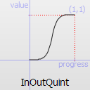

`Easing.OutInQuint`

Easing curve for a quintic (t^5) function: deceleration until halfway, then acceleration.

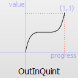

`Easing.InSine`

Easing curve for a sinusoidal (sin(t)) function: accelerating from zero velocity.

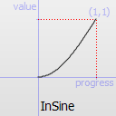

`Easing.OutSine`

Easing curve for a sinusoidal (sin(t)) function: decelerating to zero velocity.

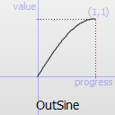

`Easing.InOutSine`

Easing curve for a sinusoidal (sin(t)) function: acceleration until halfway, then deceleration.

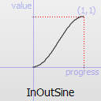

`Easing.OutInSine`

Easing curve for a sinusoidal (sin(t)) function: deceleration until halfway, then acceleration.

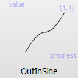

`Easing.InExpo`

Easing curve for an exponential (2^t) function: accelerating from zero velocity.

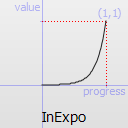

`Easing.OutExpo`

Easing curve for an exponential (2^t) function: decelerating to zero velocity.

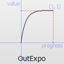

`Easing.InOutExpo`

Easing curve for an exponential (2^t) function: acceleration until halfway, then deceleration.

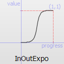

`Easing.OutInExpo`

Easing curve for an exponential (2^t) function: deceleration until halfway, then acceleration.

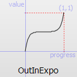

`Easing.InCirc`

Easing curve for a circular (sqrt(1-t^2)) function: accelerating from zero velocity.

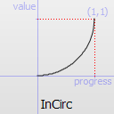

`Easing.OutCirc`

Easing curve for a circular (sqrt(1-t^2)) function: decelerating to zero velocity.

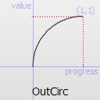

`Easing.InOutCirc`

Easing curve for a circular (sqrt(1-t^2)) function: acceleration until halfway, then deceleration.

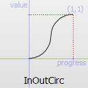

`Easing.OutInCirc`

Easing curve for a circular (sqrt(1-t^2)) function: deceleration until halfway, then acceleration.

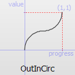

`Easing.InElastic`

Easing curve for an elastic (exponentially decaying sine wave) function: accelerating from zero velocity.  
The peak amplitude can be set with the *amplitude* parameter, and the period of decay by the *period* parameter.

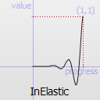

`Easing.OutElastic`

Easing curve for an elastic (exponentially decaying sine wave) function: decelerating to zero velocity.  
The peak amplitude can be set with the *amplitude* parameter, and the period of decay by the *period* parameter.

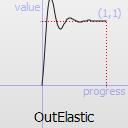

`Easing.InOutElastic`